# Class Project: Preliminary Exploratory Data Analysis

Camp Nou Analyst

# Guiding Question

**How did FC Barcelona’s overall performance metrics (goals, wins, possession, and points) change before and after Lionel Messi’s departure in 2021?**

### Why this question matters

Lionel Messi’s departure in 2021 represents a clear “before vs after” moment in modern football, making it a natural case study for performance change. Barcelona’s identity has historically been tied to possession-heavy play and high attacking output, so it is useful to quantify whether the team experienced a temporary dip or a lasting structural decline. By comparing wins, points, and goal production across seasons, this analysis provides an evidence-based way to describe how team performance shifted after a major roster change.

# Become Acquainted with the Data Sources

## Primary Data Source (football-data.co.uk)

- **Where found:** https://www.football-data.co.uk/spainm.php
- **Who collected/maintains it:** Football-Data.co.uk (public match-level data repository).
- **What a case represents:** One row represents one La Liga match (home vs away) with final score, result, and match statistics (shots, cards, etc.).
- **Seasons used:** 2018–19 through 2023–24 (six seasons).
- **Why chosen:** Provides match-level results needed to compute Barcelona’s seasonal goals, points, and win rate before vs after 2021.

## Secondary Data Source (DataHub season files)

- **Where found:** https://datahub.io/core/spanish-la-liga
- **Who collected/maintains it:** DataHub open data community.
- **What a case represents:** One row represents one La Liga match with outcomes and match-level variables similar to the primary source.
- **Seasons used:** 2018–19 through 2023–24 (six season files).
- **Purpose in this project:** Used as an independent second source for verification. I join (match) Barcelona games across sources after cleaning key fields (season/team names) to check whether records align and to demonstrate joining skills.

```r
knitr::opts_chunk$set(echo = TRUE, message = FALSE, warning = FALSE)
knitr::opts_knit$set(root.dir = getwd())

library(tidyverse)
library(readr)
library(stringr)

stopifnot(dir.exists("data"))

# ============================================================
# Primary Source: football-data.co.uk match files
# ============================================================

match_files <- list.files("data", pattern = "FootballData\\.csv$", full.names = TRUE)
match_files
```

```
[1] "data/2018-19 FootballData.csv" "data/2019-20 FootballData.csv" "data/2020-21 FootballData.csv"
[4] "data/2021-22 FootballData.csv" "data/2022-23 FootballData.csv" "data/2023-24 FootballData.csv"
```

```r
stopifnot(length(match_files) == 6)

laliga_matches <- match_files %>%
  map_dfr(~ read_csv(.x, show_col_types = FALSE) %>%
            mutate(Season = str_extract(.x, "\\d{4}-\\d{2}")))

glimpse(laliga_matches)
```

```
Rows: 2,280
Columns: 124
$ Div         <chr> "SP1", "SP1", "SP1", "SP1", "SP1", "SP1", "SP1", "SP1", "SP1", "SP1", "SP1", "SP1", "S…
$ Date        <chr> "17/08/2018", "17/08/2018", "18/08/2018", "18/08/2018", "18/08/2018", "19/08/2018", "1…
$ HomeTeam    <chr> "Betis", "Girona", "Barcelona", "Celta", "Villarreal", "Eibar", "Real Madrid", "Vallec…
$ AwayTeam    <chr> "Levante", "Valladolid", "Alaves", "Espanol", "Sociedad", "Huesca", "Getafe", "Sevilla…
$ FTHG        <dbl> 0, 0, 3, 1, 1, 1, 2, 1, 2, 1, 2, 2, 0, 1, 0, 2, 1, 0, 2, 1, 2, 0, 0, 2, 4, 2, 8, 1, 2,…
$ FTAG        <dbl> 3, 0, 0, 1, 2, 2, 0, 4, 1, 1, 0, 2, 0, 0, 1, 0, 4, 0, 2, 2, 1, 0, 1, 0, 1, 1, 2, 0, 2,…
$ FTR         <chr> "A", "D", "H", "D", "A", "A", "H", "A", "H", "D", "H", "D", "D", "H", "A", "H", "A", "…
$ HTHG        <dbl> 0, 0, 0, 0, 1, 0, 1, 0, 1, 0, 1, 0, 0, 0, 0, 0, 1, 0, 0, 0, 1, 0, 0, 0, 1, 0, 3, 0, 2,…
$ HTAG        <dbl> 1, 0, 0, 1, 1, 2, 0, 3, 1, 1, 0, 2, 0, 0, 0, 0, 1, 0, 0, 2, 1, 0, 0, 0, 1, 1, 2, 0, 1,…
$ HTR         <chr> "A", "D", "D", "A", "D", "A", "H", "A", "D", "A", "H", "A", "D", "D", "D", "D", "D", "…
$ HS          <dbl> 22, 13, 25, 12, 16, 18, 10, 13, 17, 13, 7, 18, 16, 9, 7, 19, 10, 19, 14, 15, 8, 12, 13…
$ AS          <dbl> 6, 2, 3, 14, 8, 8, 4, 17, 12, 9, 9, 7, 13, 13, 10, 16, 20, 14, 9, 21, 7, 7, 14, 9, 8, …
$ HST         <dbl> 8, 1, 9, 2, 7, 6, 3, 2, 5, 4, 4, 5, 4, 2, 4, 9, 5, 2, 4, 6, 2, 3, 3, 4, 8, 5, 15, 3, 4…
```

[output cut: 111 more lines]

```r
count(laliga_matches, Season)
```

| Season | n |
| --- | --- |
| 2018-19 | 380 |
| 2019-20 | 380 |
| 2020-21 | 380 |
| 2021-22 | 380 |
| 2022-23 | 380 |
| 2023-24 | 380 |

```r
# ============================================================
# Secondary Source: "DataHub" match files
# ============================================================

datahub_files <- list.files("data", pattern = "DataHub\\.csv$", full.names = TRUE)
datahub_files
```

```
[1] "data/season-1819 DataHub.csv" "data/season-1920 DataHub.csv" "data/season-2021 DataHub.csv"
[4] "data/season-2122 DataHub.csv" "data/season-2223 DataHub.csv" "data/season-2324 DataHub.csv"
```

```r
stopifnot(length(datahub_files) == 6)

laliga_datahub <- datahub_files %>%
  map_dfr(~ read_csv(.x, show_col_types = FALSE) %>%
            mutate(
              Season = case_when(
                str_detect(.x, "1819") ~ "2018-19",
                str_detect(.x, "1920") ~ "2019-20",
                str_detect(.x, "2021") ~ "2020-21",
                str_detect(.x, "2122") ~ "2021-22",
                str_detect(.x, "2223") ~ "2022-23",
                str_detect(.x, "2324") ~ "2023-24",
                TRUE ~ NA_character_
              )
            ))

glimpse(laliga_datahub)
```

```
Rows: 2,280
Columns: 23
$ Date     <chr> "17/08/18", "17/08/18", "18/08/18", "18/08/18", "18/08/18", "19/08/18", "19/08/18", "19/0…
$ HomeTeam <chr> "Betis", "Girona", "Barcelona", "Celta", "Villarreal", "Eibar", "Real Madrid", "Vallecano…
$ AwayTeam <chr> "Levante", "Valladolid", "Alaves", "Espanol", "Sociedad", "Huesca", "Getafe", "Sevilla", …
$ FTHG     <dbl> 0, 0, 3, 1, 1, 1, 2, 1, 2, 1, 2, 2, 0, 1, 0, 2, 1, 0, 2, 1, 2, 0, 0, 2, 4, 2, 8, 1, 2, 0,…
$ FTAG     <dbl> 3, 0, 0, 1, 2, 2, 0, 4, 1, 1, 0, 2, 0, 0, 1, 0, 4, 0, 2, 2, 1, 0, 1, 0, 1, 1, 2, 0, 2, 1,…
$ FTR      <chr> "A", "D", "H", "D", "A", "A", "H", "A", "H", "D", "H", "D", "D", "H", "A", "H", "A", "D",…
$ HTHG     <dbl> 0, 0, 0, 0, 1, 0, 1, 0, 1, 0, 1, 0, 0, 0, 0, 0, 1, 0, 0, 0, 1, 0, 0, 0, 1, 0, 3, 0, 2, 0,…
$ HTAG     <dbl> 1, 0, 0, 1, 1, 2, 0, 3, 1, 1, 0, 2, 0, 0, 0, 0, 1, 0, 0, 2, 1, 0, 0, 0, 1, 1, 2, 0, 1, 1,…
$ HTR      <chr> "A", "D", "D", "A", "D", "A", "H", "A", "D", "A", "H", "A", "D", "D", "D", "D", "D", "D",…
$ Referee  <lgl> NA, NA, NA, NA, NA, NA, NA, NA, NA, NA, NA, NA, NA, NA, NA, NA, NA, NA, NA, NA, NA, NA, N…
$ HS       <dbl> 22, 13, 25, 12, 16, 18, 10, 13, 17, 13, 7, 18, 16, 9, 7, 19, 10, 19, 14, 15, 8, 12, 13, 1…
$ AS       <dbl> 6, 2, 3, 14, 8, 8, 4, 17, 12, 9, 9, 7, 13, 13, 10, 16, 20, 14, 9, 21, 7, 7, 14, 9, 8, 11,…
$ HST      <dbl> 8, 1, 9, 2, 7, 6, 3, 2, 5, 4, 4, 5, 4, 2, 4, 9, 5, 2, 4, 6, 2, 3, 3, 4, 8, 5, 15, 3, 4, 4…
$ AST      <dbl> 4, 1, 0, 5, 4, 6, 1, 8, 2, 3, 0, 6, 5, 3, 5, 4, 8, 6, 4, 9, 2, 4, 6, 0, 3, 7, 3, 2, 5, 2,…
$ HF       <dbl> 10, 21, 6, 13, 16, 12, 11, 6, 12, 10, 14, 12, 17, 7, 13, 16, 13, 13, 17, 14, 18, 22, 15, …
$ AF       <dbl> 10, 20, 13, 14, 10, 13, 27, 15, 13, 15, 11, 9, 15, 8, 11, 12, 11, 14, 17, 8, 15, 14, 11, …
$ HC       <dbl> 5, 3, 7, 8, 4, 7, 3, 2, 6, 4, 5, 5, 5, 8, 6, 6, 4, 4, 3, 7, 4, 6, 7, 2, 8, 0, 9, 5, 3, 6,…
$ AC       <dbl> 3, 2, 1, 7, 6, 0, 0, 6, 2, 10, 5, 0, 6, 5, 10, 10, 7, 5, 2, 7, 2, 7, 2, 8, 1, 12, 4, 8, 5…
$ HY       <dbl> 0, 1, 0, 3, 2, 1, 1, 1, 4, 2, 2, 1, 3, 1, 1, 1, 2, 3, 2, 2, 3, 3, 3, 4, 1, 4, 1, 3, 4, 2,…
$ AY       <dbl> 2, 1, 2, 2, 3, 1, 7, 0, 5, 3, 1, 2, 1, 1, 1, 1, 3, 2, 2, 3, 2, 1, 2, 5, 1, 3, 2, 6, 2, 1,…
$ HR       <dbl> 0, 0, 0, 0, 0, 0, 0, 0, 0, 0, 0, 0, 0, 0, 0, 0, 0, 0, 0, 0, 0, 0, 0, 0, 0, 0, 0, 0, 1, 0,…
$ AR       <dbl> 0, 0, 0, 0, 0, 0, 0, 0, 0, 0, 0, 0, 0, 0, 0, 0, 0, 0, 0, 0, 0, 0, 0, 1, 0, 0, 0, 1, 0, 0,…
$ Season   <chr> "2018-19", "2018-19", "2018-19", "2018-19", "2018-19", "2018-19", "2018-19", "2018-19", "…
```

```r
count(laliga_datahub, Season)
```

| Season | n |
| --- | --- |
| 2018-19 | 380 |
| 2019-20 | 380 |
| 2020-21 | 380 |
| 2021-22 | 380 |
| 2022-23 | 380 |
| 2023-24 | 380 |

```r
# Ensuring both sources have the required key columns for joining
required_cols <- c("Date","HomeTeam","AwayTeam","FTHG","FTAG","FTR","Season")
stopifnot(all(required_cols %in% names(laliga_matches)))
stopifnot(all(required_cols %in% names(laliga_datahub)))
```

# Analysis Plan

1. **Filter matches involving Barcelona** from the primary match dataset.
2. **Create match-derived metrics** for Barcelona (goals for/against, match result, and points earned).
3. **Aggregate by season** to compute total points, wins/draws/losses, goals, and per-match rates.
4. **Label seasons as “Before Messi” vs “After Messi”** (before: 2018–19 through 2020–21; after: 2021–22 through 2023–24).
5. **Join with the secondary dataset** (DataHub match files) using cleaned keys to validate that Barcelona match records are consistent across sources.
6. **Visualize key comparisons** aligned with the guiding question: points per match, goals scored per match, goals conceded per match, and win rate.

```r
library(scales)

# ============================================================
# 1) Barcelona matches from PRIMARY source (FootballData)
# ============================================================

barcelona_matches <- laliga_matches %>%
  filter(HomeTeam == "Barcelona" | AwayTeam == "Barcelona") %>%
  mutate(
    BarcaIsHome = HomeTeam == "Barcelona",
    GoalsFor = if_else(BarcaIsHome, FTHG, FTAG),
    GoalsAgainst = if_else(BarcaIsHome, FTAG, FTHG),
    Result = case_when(
      (FTR == "H" & BarcaIsHome) ~ "Win",
      (FTR == "A" & !BarcaIsHome) ~ "Win",
      FTR == "D" ~ "Draw",
      TRUE ~ "Loss"
    ),
    Points = case_when(
      Result == "Win" ~ 3,
      Result == "Draw" ~ 1,
      TRUE ~ 0
    )
  )

glimpse(barcelona_matches)
```

```
Rows: 228
Columns: 129
$ Div          <chr> "SP1", "SP1", "SP1", "SP1", "SP1", "SP1", "SP1", "SP1", "SP1", "SP1", "SP1", "SP1", "…
$ Date         <chr> "18/08/2018", "25/08/2018", "02/09/2018", "15/09/2018", "23/09/2018", "26/09/2018", "…
$ HomeTeam     <chr> "Barcelona", "Valladolid", "Barcelona", "Sociedad", "Barcelona", "Leganes", "Barcelon…
$ AwayTeam     <chr> "Alaves", "Barcelona", "Huesca", "Barcelona", "Girona", "Barcelona", "Ath Bilbao", "B…
$ FTHG         <dbl> 3, 0, 8, 1, 2, 2, 1, 1, 4, 5, 2, 3, 1, 2, 0, 0, 2, 1, 3, 3, 0, 2, 0, 1, 2, 0, 3, 1, 2…
$ FTAG         <dbl> 0, 1, 2, 2, 2, 1, 1, 1, 2, 1, 3, 4, 1, 0, 4, 5, 0, 2, 0, 1, 2, 2, 0, 0, 4, 1, 1, 4, 0…
$ FTR          <chr> "H", "A", "H", "A", "D", "H", "D", "D", "H", "H", "A", "A", "D", "H", "A", "A", "H", …
$ HTHG         <dbl> 0, 0, 3, 1, 1, 0, 0, 1, 2, 2, 1, 0, 0, 1, 0, 0, 2, 1, 1, 1, 0, 1, 0, 1, 2, 0, 1, 0, 0…
$ HTAG         <dbl> 0, 0, 2, 0, 1, 1, 1, 1, 0, 0, 1, 2, 0, 0, 3, 2, 0, 2, 0, 0, 1, 2, 0, 0, 1, 1, 1, 2, 0…
$ HTR          <chr> "D", "D", "H", "H", "D", "A", "A", "D", "H", "H", "D", "A", "D", "H", "A", "A", "H", …
$ HS           <dbl> 25, 7, 31, 8, 22, 10, 20, 10, 23, 13, 11, 20, 3, 16, 15, 20, 9, 10, 7, 15, 13, 20, 13…
$ AS           <dbl> 3, 10, 7, 12, 7, 9, 8, 10, 19, 15, 9, 15, 8, 12, 17, 16, 11, 12, 15, 5, 15, 14, 10, 1…
$ HST          <dbl> 9, 4, 15, 5, 11, 6, 8, 3, 9, 8, 5, 5, 1, 7, 3, 6, 5, 2, 6, 7, 5, 8, 5, 8, 4, 3, 6, 3,…
```

[output cut: 116 more lines]

```r
count(barcelona_matches, Season, Result)
```

| Season | Result | n |
| --- | --- | --- |
| 2018-19 | Draw | 9 |
| 2018-19 | Loss | 3 |
| 2018-19 | Win | 26 |
| 2019-20 | Draw | 7 |
| 2019-20 | Loss | 6 |
| 2019-20 | Win | 25 |
| 2020-21 | Draw | 7 |
| 2020-21 | Loss | 7 |
| 2020-21 | Win | 24 |
| 2021-22 | Draw | 10 |

[output cut: 8 more lines]

```r
# ============================================================
# 2) Per-season Barcelona summary (computed from match-level)
# ============================================================

barca_summary <- barcelona_matches %>%
  group_by(Season) %>%
  summarise(
    Matches = n(),
    Wins = sum(Result == "Win"),
    Draws = sum(Result == "Draw"),
    Losses = sum(Result == "Loss"),
    GoalsFor = sum(GoalsFor),
    GoalsAgainst = sum(GoalsAgainst),
    GoalDifference = GoalsFor - GoalsAgainst,
    Points = sum(Points),
    .groups = "drop"
  ) %>%
  mutate(
    PointsPerMatch = Points / Matches,
    GoalsForPerMatch = GoalsFor / Matches,
    GoalsAgainstPerMatch = GoalsAgainst / Matches,
    Period = if_else(Season %in% c("2018-19","2019-20","2020-21"),
                     "Before Messi", "After Messi"),
    Period = factor(Period, levels = c("Before Messi","After Messi"))
  )

barca_summary
```

| Season | Matches | Wins | Draws | Losses | GoalsFor | GoalsAgainst | GoalDifference | Points | PointsPerMatch | GoalsForPerMatch | GoalsAgainstPerMatch | Period |
| --- | --- | --- | --- | --- | --- | --- | --- | --- | --- | --- | --- | --- |
| 2018-19 | 38 | 26 | 9 | 3 | 90 | 36 | 54 | 87 | 2.289474 | 2.368421 | 0.9473684 | Before Messi |
| 2019-20 | 38 | 25 | 7 | 6 | 86 | 38 | 48 | 82 | 2.157895 | 2.263158 | 1.0000000 | Before Messi |
| 2020-21 | 38 | 24 | 7 | 7 | 85 | 38 | 47 | 79 | 2.078947 | 2.236842 | 1.0000000 | Before Messi |
| 2021-22 | 38 | 21 | 10 | 7 | 68 | 38 | 30 | 73 | 1.921053 | 1.789474 | 1.0000000 | After Messi |
| 2022-23 | 38 | 28 | 4 | 6 | 70 | 20 | 50 | 88 | 2.315789 | 1.842105 | 0.5263158 | After Messi |
| 2023-24 | 38 | 26 | 7 | 5 | 79 | 44 | 35 | 85 | 2.236842 | 2.078947 | 1.1578947 | After Messi |

```r
barca_season_summary <- barca_summary %>%
  group_by(Period) %>%
  summarise(
    AvgPointsPerMatch = mean(PointsPerMatch),
    AvgGoalsForPerMatch = mean(GoalsForPerMatch),
    AvgGoalsAgainstPerMatch = mean(GoalsAgainstPerMatch),
    TotalWins = sum(Wins),
    TotalMatches = sum(Matches),
    WinRate = TotalWins / TotalMatches * 100,
    .groups = "drop"
  )

barca_season_summary
```

| Period | AvgPointsPerMatch | AvgGoalsForPerMatch | AvgGoalsAgainstPerMatch | TotalWins | TotalMatches | WinRate |
| --- | --- | --- | --- | --- | --- | --- |
| Before Messi | 2.175439 | 2.289474 | 0.9824561 | 75 | 114 | 65.78947 |
| After Messi | 2.157895 | 1.903509 | 0.8947368 | 75 | 114 | 65.78947 |

```r
# ============================================================
# 3) JOIN with SECONDARY source (DataHub match files)
# ============================================================

barca_primary_keys <- barcelona_matches %>%
  select(HomeTeam, AwayTeam, FTHG, FTAG, FTR, Season)

barca_secondary_keys <- laliga_datahub %>%
  filter(HomeTeam == "Barcelona" | AwayTeam == "Barcelona") %>%
  select(HomeTeam, AwayTeam, FTHG, FTAG, FTR, Season)

# Using an inner_join to see matched rows
barca_joined_matches <- barca_primary_keys %>%
  inner_join(barca_secondary_keys,
             by = c("HomeTeam","AwayTeam","FTHG","FTAG","FTR","Season"))

# Rows in primary but NOT in secondary
barca_primary_not_in_secondary <- barca_primary_keys %>%
  anti_join(barca_secondary_keys,
            by = c("HomeTeam","AwayTeam","FTHG","FTAG","FTR","Season"))

# Rows in secondary but NOT in primary
barca_secondary_not_in_primary <- barca_secondary_keys %>%
  anti_join(barca_primary_keys,
            by = c("HomeTeam","AwayTeam","FTHG","FTAG","FTR","Season"))

nrow(barca_joined_matches)
```

```
[1] 228
```

```r
nrow(barca_primary_not_in_secondary)
```

```
[1] 0
```

```r
nrow(barca_secondary_not_in_primary)
```

```
[1] 0
```

```r
# If any mismatches exist, show a small sample
head(barca_primary_not_in_secondary, 10)
```

| HomeTeam | AwayTeam | FTHG | FTAG | FTR | Season |
| --- | --- | --- | --- | --- | --- |

```r
head(barca_secondary_not_in_primary, 10)
```

| HomeTeam | AwayTeam | FTHG | FTAG | FTR | Season |
| --- | --- | --- | --- | --- | --- |

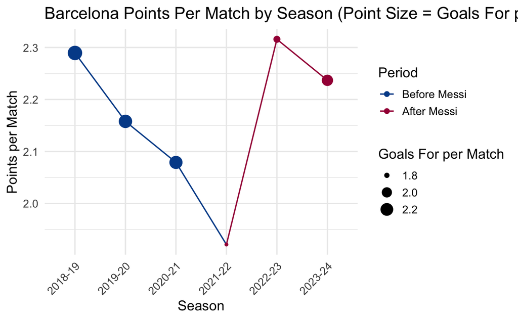

```r
# ============================================================
# 4) VISUALIZATIONS
# ============================================================

theme_set(theme_minimal(base_size = 14))
barca_colors <- c("Before Messi" = "#004D98", "After Messi" = "#A50044")

# (A) Season + PointsPerMatch + Period + GoalsForPerMatch
ggplot(barca_summary, aes(x = Season, y = PointsPerMatch, color = Period, group = 1)) +
  geom_line() +
  geom_point(aes(size = GoalsForPerMatch)) +
  scale_color_manual(values = barca_colors) +
  labs(
    title = "Barcelona Points Per Match by Season (Point Size = Goals For per Match)",
    x = "Season",
    y = "Points per Match",
    color = "Period",
    size = "Goals For per Match"
  ) +
  theme(axis.text.x = element_text(angle = 45, hjust = 1))
```